# R 분류분석 : 중산층 여부 예측하기

2017 . 10 . 02

’따라하며 배우는 데이터과학’책의 8장 내용을 정리한 것입니다.

UCI 머신러닝 예제 데이터 아카이브의 ’Adult’데이터를 사용하였다.(https://goo.gl/yVK0qq)

### - 순서

#### 1. 데이터 로드와 데이터 구조 파악하기

#### 2. 훈련, 검증, 테스트세트로 분할

#### 3. 시각화로 데이터 탐색하기 EDA

##### 1) 나이(age)와 중산층 여부(wage)의 관계

##### 2) 인종, 성별, 나이 세 변수와 중산층 여부의 관계

##### 3) 총 교육기간과 중산층 여부의 관계

#### 4. 모형적합 - 로지스틱 회귀

#### 5. glm로지스틱회귀모형으로 예측하기

```r
library(dplyr)
library(ggplot2)
library(ISLR)
library(MASS)
library(glmnet)
library(randomForest)
library(gbm)
library(rpart)
library(boot)
```

### 1. 데이터 로드와 데이터 구조 파악하기

#### R에 데이터 파일을 읽어 들이고 변수명을 지정하기

(strip.white = TRUE 옵션은 데이터 파일에서 콤마 다음의 공백문자를 제거한다.)

```r
setwd("/Users/jang-eun-a/stat-methods")
adult <- read.csv("adult.data.csv", header = FALSE, strip.white = TRUE)
names(adult) <- c('age', 'workclass', 'fnlwgt', 'education',
                  'education_num', 'merital_status', 'occupation',
                  'relationship', 'race', 'sex', 'capital_gain', 'capital_loss',
                  'hours_per_week', 'native_country', 'wage')
```

그리고 glimpse() 명령으로 데이터 구조를 살펴보자

```r
glimpse(adult)
```

```
Observations: 32,561
Variables: 15
$ age            <int> 39, 50, 38, 53, 28, 37, 49, 52, 31, 42, 37, 30, 2...
$ workclass      <fctr> State-gov, Self-emp-not-inc, Private, Private, P...
$ fnlwgt         <int> 77516, 83311, 215646, 234721, 338409, 284582, 160...
$ education      <fctr> Bachelors, Bachelors, HS-grad, 11th, Bachelors, ...
$ education_num  <int> 13, 13, 9, 7, 13, 14, 5, 9, 14, 13, 10, 13, 13, 1...
$ merital_status <fctr> Never-married, Married-civ-spouse, Divorced, Mar...
$ occupation     <fctr> Adm-clerical, Exec-managerial, Handlers-cleaners...
$ relationship   <fctr> Not-in-family, Husband, Not-in-family, Husband, ...
$ race           <fctr> White, White, White, Black, Black, White, Black,...
$ sex            <fctr> Male, Male, Male, Male, Female, Female, Female, ...
$ capital_gain   <int> 2174, 0, 0, 0, 0, 0, 0, 0, 14084, 5178, 0, 0, 0, ...
$ capital_loss   <int> 0, 0, 0, 0, 0, 0, 0, 0, 0, 0, 0, 0, 0, 0, 0, 0, 0...
$ hours_per_week <int> 40, 13, 40, 40, 40, 40, 16, 45, 50, 40, 80, 40, 3...
$ native_country <fctr> United-States, United-States, United-States, Uni...
$ wage           <fctr> <=50K, <=50K, <=50K, <=50K, <=50K, <=50K, <=50K,...
```

분석 목표는 다른 변수들을 사용해 마지막 변수 wage를 예측하는것

```r
summary(adult)
```

```
      age                   workclass         fnlwgt
 Min.   :17.00   Private         :22696   Min.   :  12285
 1st Qu.:28.00   Self-emp-not-inc: 2541   1st Qu.: 117827
 Median :37.00   Local-gov       : 2093   Median : 178356
 Mean   :38.58   ?               : 1836   Mean   : 189778
 3rd Qu.:48.00   State-gov       : 1298   3rd Qu.: 237051
 Max.   :90.00   Self-emp-inc    : 1116   Max.   :1484705
                 (Other)         :  981
        education     education_num                 merital_status
 HS-grad     :10501   Min.   : 1.00   Divorced             : 4443
 Some-college: 7291   1st Qu.: 9.00   Married-AF-spouse    :   23
 Bachelors   : 5355   Median :10.00   Married-civ-spouse   :14976
 Masters     : 1723   Mean   :10.08   Married-spouse-absent:  418
 Assoc-voc   : 1382   3rd Qu.:12.00   Never-married        :10683
 11th        : 1175   Max.   :16.00   Separated            : 1025
 (Other)     : 5134                   Widowed              :  993
           occupation           relationship                   race
 Prof-specialty :4140   Husband       :13193   Amer-Indian-Eskimo:  311
 Craft-repair   :4099   Not-in-family : 8305   Asian-Pac-Islander: 1039
 Exec-managerial:4066   Other-relative:  981   Black             : 3124
 Adm-clerical   :3770   Own-child     : 5068   Other             :  271
 Sales          :3650   Unmarried     : 3446   White             :27816
 Other-service  :3295   Wife          : 1568
 (Other)        :9541
     sex         capital_gain    capital_loss    hours_per_week
 Female:10771   Min.   :    0   Min.   :   0.0   Min.   : 1.00
 Male  :21790   1st Qu.:    0   1st Qu.:   0.0   1st Qu.:40.00
                Median :    0   Median :   0.0   Median :40.00
                Mean   : 1078   Mean   :  87.3   Mean   :40.44
                3rd Qu.:    0   3rd Qu.:   0.0   3rd Qu.:45.00
                Max.   :99999   Max.   :4356.0   Max.   :99.00

       native_country     wage
 United-States:29170   <=50K:24720
 Mexico       :  643   >50K : 7841
 ?            :  583
 Philippines  :  198
 Germany      :  137
 Canada       :  121
 (Other)      : 1709
```

데이터 구조 파악 결과 절반 정도의 설명변수는 범주형 변수임을 알 수 있다.

**반응변수의 변수형 알아보기**

factor 타입으로 “<=50k”와 “>50k”의 레벨을 가지고 있으며 각 레벨은 내부적으로 수치값 1과 2에 대응한다.

```r
levels(adult$wage)
```

```
[1] "<=50K" ">50K"
```

### 2. 훈련, 검증, 테스트세트로 분할

60:20:20

```r
set.seed(1002)
n <- nrow(adult)
idx <- 1:n
training_idx <- sample(idx, n * .60)
idx <- setdiff(idx, training_idx)
validate_idx = sample(idx, n * .20)
test_idx <- setdiff(idx, validate_idx)
length(training_idx)
```

```
[1] 19536
```

```r
length(validate_idx)
```

```
[1] 6512
```

```r
length(test_idx)
```

```
[1] 6513
```

```r
training <- adult[training_idx, ]
validation <- adult[validate_idx, ]
test <- adult[test_idx, ]
```

### 3. 시각화로 데이터 탐색하기 EDA

#### 1) 나이(age)와 중산층 여부(wage)의 관계

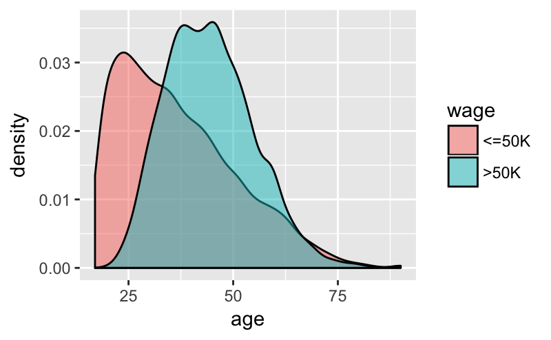

```r
training %>%
  ggplot(aes(age, fill=wage)) +
  geom_density(alpha=.5)
```

#### 2) 인종, 성별, 나이 세 변수와 중산층 여부의 관계

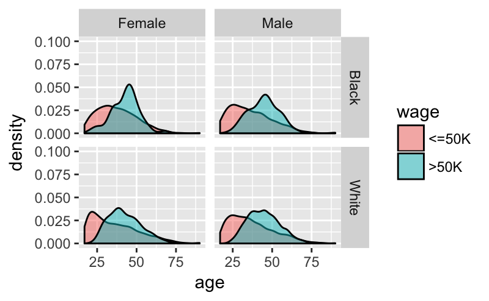

```r
training %>%
  filter(race %in% c('Black','White')) %>%
  ggplot(aes(age, fill=wage)) +
  geom_density(alpha = .5) +
  ylim(0, 0.1) +
  facet_grid(race ~ sex, scales = 'free_y')
```

- 나이-중산층 여부의 관계가 남성인 경우에 흑인이나 백인이나 유사하다.
- 하지만 여성일 경우, 흑인의 경우 중장년층에서만 중산층의 비율이 높고 노년층의 경우에는 대부분 소득이 낮은 것을 볼 수 있다.
- 백인 여성의 경우는 28~70세 동안에 >50k 비율이 높지만, 흑인 여성의 경우에는 그 연령대가 32~55세 정도에 불과하다.

#### 3) 총 교육기간과 중산층 여부의 관계

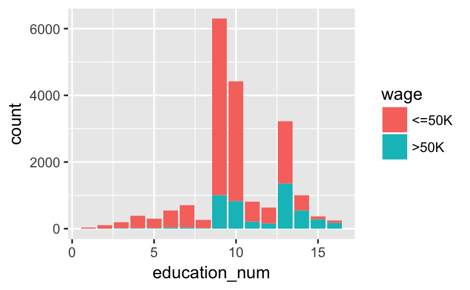

```r
training %>%
  ggplot(aes(education_num, fill=wage)) +
  geom_bar()
```

당연한 결과로 education_num이 증가할수록 중산층 비율이 높아짐을 확인할 수 있다.

### 4. 모형적합 - 로지스틱 회귀

모든 설명변수를 사용해서 로지스틱 회귀 모형에 넣어본다.

```r
ad_glm_full <- glm(wage ~ . , data=training, family = binomial)
```

```
glm.fit: 적합된 확률값들이 0 또는 1 입니다
```

여기서 경고 메세지가 뜨는 이유 : 일부 설명변수의 조합에서 반응변수가 완벽하게 0이거나 1일 경우가 있기 때문이다.

##### 해결방법

- glmnet 같은 정규화된 모형(regularized model)을 사용한다.
- 모형을 변경한다. 변수선택을 시도한다. 범주형 변수의 경우에는 레벨을 줄여본다.
- 베이지안 분석을 한다.
- 내버려둔다. 신회구간은 왜곡되지만 모형 자체는 쓸만 할 수 있다.

#### 적합된 모형 살펴보기

적합된 모형에서 어떤 변수들이 통계적으로 유의하게 나타나는지를 살펴보자.

```r
summary(ad_glm_full)
```

```
Call:
glm(formula = wage ~ ., family = binomial, data = training)

Deviance Residuals:
    Min       1Q   Median       3Q      Max
-3.2464  -0.5026  -0.1787  -0.0006   3.4507

Coefficients: (2 not defined because of singularities)
                                           Estimate Std. Error z value
(Intercept)                              -8.280e+00  6.011e-01 -13.775
age                                       2.683e-02  2.149e-03  12.482
workclassFederal-gov                      1.190e+00  1.984e-01   6.001
workclassLocal-gov                        4.468e-01  1.808e-01   2.471
workclassNever-worked                    -9.184e+00  1.644e+03  -0.006
workclassPrivate                          5.970e-01  1.607e-01   3.715
workclassSelf-emp-inc                     8.248e-01  1.944e-01   4.243
workclassSelf-emp-not-inc                 1.334e-01  1.754e-01   0.761
workclassState-gov                        2.238e-01  1.961e-01   1.141
workclassWithout-pay                     -1.438e+01  7.535e+02  -0.019
fnlwgt                                    5.263e-07  2.272e-07   2.316
education11th                             2.614e-01  2.737e-01   0.955
education12th                             6.438e-01  3.453e-01   1.864
education1st-4th                         -4.697e-01  6.313e-01  -0.744
education5th-6th                          9.216e-02  4.156e-01   0.222
education7th-8th                         -7.584e-01  3.308e-01  -2.293
education9th                              1.103e-01  3.275e-01   0.337
educationAssoc-acdm                       1.438e+00  2.359e-01   6.096
educationAssoc-voc                        1.436e+00  2.271e-01   6.324
educationBachelors                        2.063e+00  2.121e-01   9.728
educationDoctorate                        3.128e+00  2.844e-01  10.998
educationHS-grad                          8.694e-01  2.068e-01   4.204
educationMasters                          2.329e+00  2.256e-01  10.321
educationPreschool                       -1.922e+01  2.622e+02  -0.073
educationProf-school                      2.862e+00  2.648e-01  10.809
educationSome-college                     1.223e+00  2.096e-01   5.836
education_num                                    NA         NA      NA
merital_statusMarried-AF-spouse           1.886e+00  7.464e-01   2.527
merital_statusMarried-civ-spouse          1.496e+00  3.986e-01   3.752
merital_statusMarried-spouse-absent      -1.153e-02  3.075e-01  -0.037
merital_statusNever-married              -4.785e-01  1.133e-01  -4.225
```

[output cut: 167 more lines]

```
native_countryThailand                   0.264845
native_countryTrinadad&Tobago            0.680669
native_countryUnited-States              0.373587
native_countryVietnam                    0.252875
native_countryYugoslavia                 0.219823
---
Signif. codes:  0 ‘***’ 0.001 ‘**’ 0.01 ‘*’ 0.05 ‘.’ 0.1 ‘ ’ 1

(Dispersion parameter for binomial family taken to be 1)

    Null deviance: 21608  on 19535  degrees of freedom
Residual deviance: 12243  on 19437  degrees of freedom
AIC: 12441

Number of Fisher Scoring iterations: 15
```

출력 결과에 의하면 다음 변수가 특히 유의미한 것으로 확인된다.

- age
- workclass
- fnlwgt
- education
- occupation
- relationship - wife
- race 등

### 5. glm로지스틱회귀모형으로 예측하기

```r
yhat_lm <- predict(ad_glm_full, newdata=validation, type='response')
```

```
prediction from a rank-deficient fit may be misleading
```

[figure not shown]

#### ROC 곡선 그려보기

```r
# # install.packages("ROCR")
# library(ROCR)
# pred_lm <- prediction(y_obs, yhat_lm)
# perf_lm <- performance(pred_lm, measure = "tpr", x.measure = "fpr")
# plot(perf_lm, col='black', main="ROC Curve for GLM")
# abline(0,1)
# performance(pred_lm, "auc")@y.values[[1]]
#
#
##Error in UseMethod("predict") : 클래스 "c('double', 'numeric')"의 객체에 적용된 'predict'에 사용할수 있는 메소드가 없습니다
```

위의 에러를 해결하지 못하였다. 그래서 다른 패키지의 ROC그래프 함수를 사용하였다.

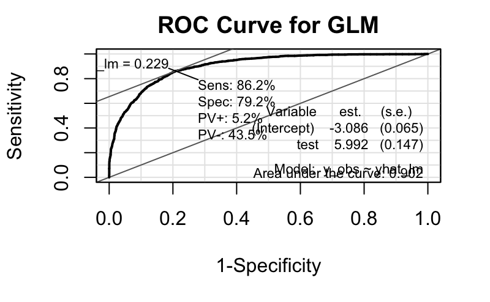

```r
# install.packages("Epi")
library(Epi)
a1=ROC(yhat_lm,y_obs, plot="ROC", main="ROC Curve for GLM" )
```